# White wine quality by Sumit Kumar Mahato

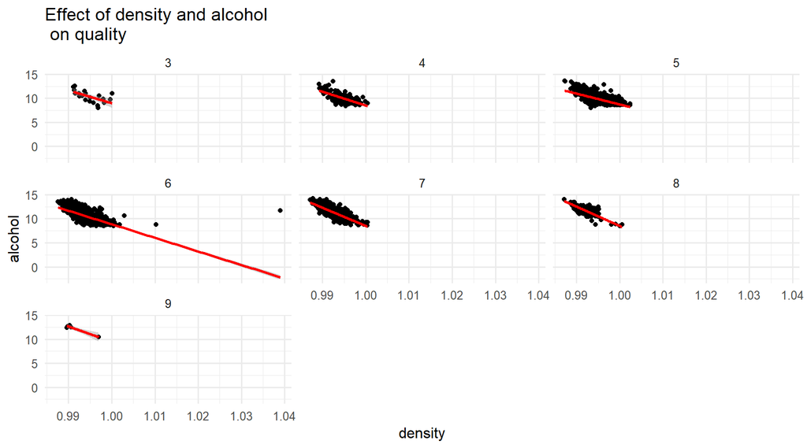

Since alcohol content and density is negatively correlated we see a downward trend in quality too. Higher the alcohol content lower will be the density and lower alcohol content reduces the quality of wine. However, we can see some high quality wines with higher density and low alcohol. These might be the sweet wines (high residual sugar) judged by judges liking for sweeter wine.

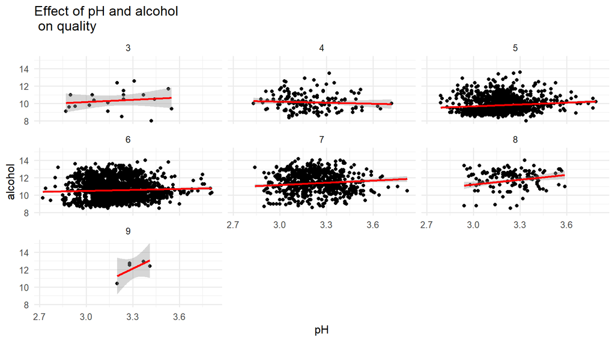

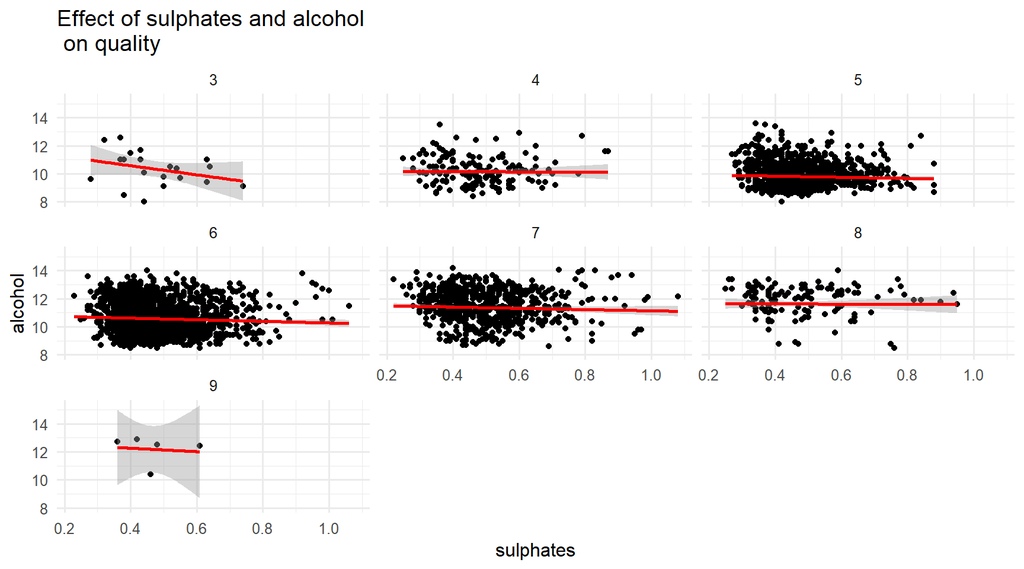

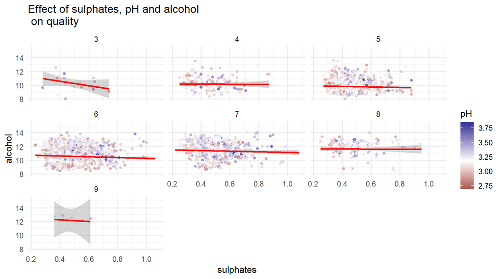

In this plot all the features postively correlated with quality are plotted together. We can see that one of the feature balances the effect of other with alcohol having the most impact.

### Talk about some of the relationships you observed in this part of the investigation. Were there features that strengthened each other in terms of looking at your feature(s) of interest?

Almost all the high quality wine i.e., with a rating 9 had alcohol content greater than 12. Similarly, almost all the wines with poor rating i.e., 3 had an alcohol content less than 12. Alcohol content strengthend almost all the features which had a negative correlation with quality.

### OPTIONAL: Did you create any models with your dataset? Discuss the strengths and limitations of your model.

I tried to fit a linear model into the dataset. The outliers tend to sway the best fit line. ——

# Final Plots and Summary

From the analysis, I found that alcohol percentage is the most important factor affecting the quality of the wine. The relationship of alcohol with quality and how it is strengthened by other positively correlated factors are explained in the following section.

### Plot One

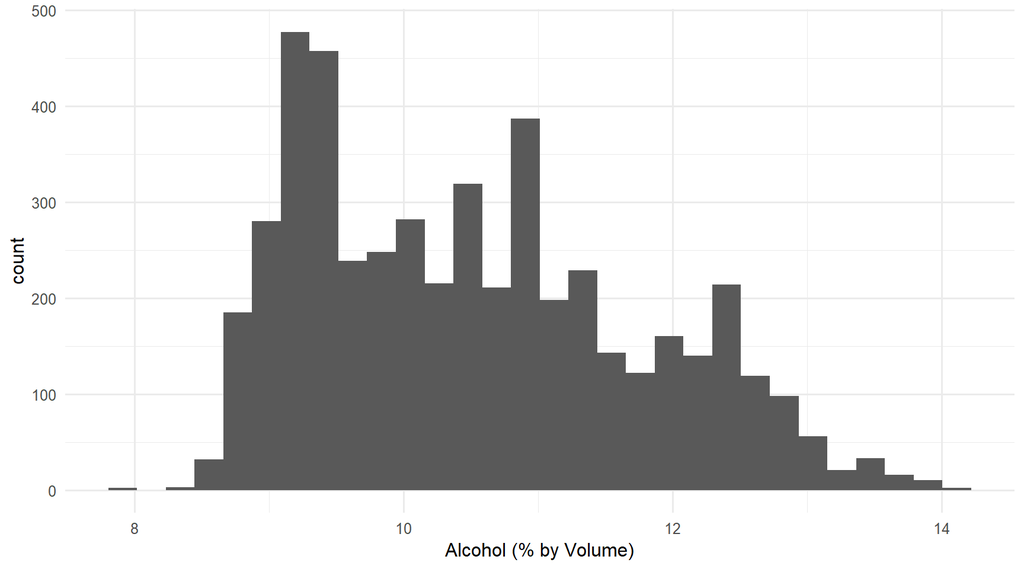

### Plot Two

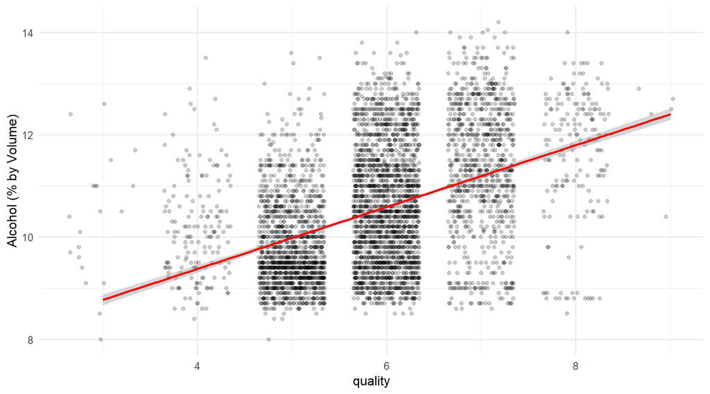

### Plot Three

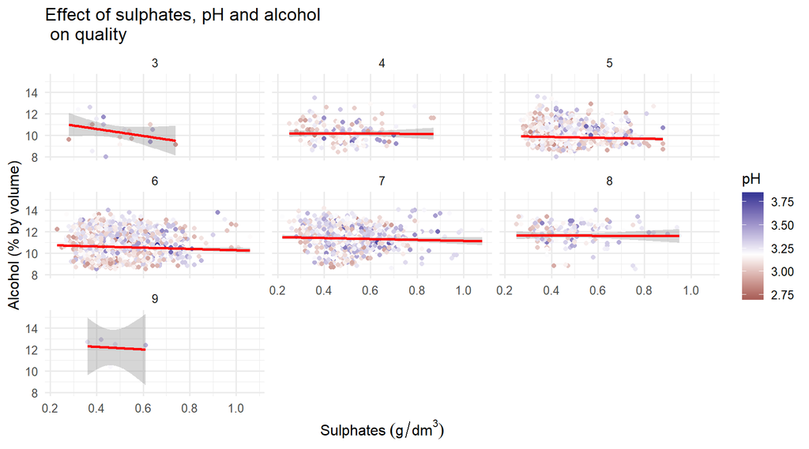

### Description Three

The above plot shows the impact of 3 positively correlated features on the feature of interest. It is worthwhile to note that all the plots have a downward slope which signifies that decrease in amount of feature is balanced by increasein other feature to retain the quality of wine.

# Reflection

This is the first time I am using R markdown and was quite confused. However, I found out that I had good amount of practice in R while going through the course videos. There were several challenges which I faced such as comparing variables on different scales, plotting all variables of a dataframe in a single plot, fitting linear model and many more. Online forums such as stack exchange and R documentation helped me overcome these challenges. I also started installing more unknown packages to find out the solution I wanted. Finally, the review I received from Udacity helped me get deeper insights into my work and also helped me improve my presentation. I am really grateful for the super helpful and concise review. At the outset, I am more confident in Exploratory data analysis and is looking forward to apply my skills on different datasets. For future work the each physicochemical feature would be ranked based on their importance in predicting quality of wine. Further, I would be like to develop a machine learning algorithm to predict the quality of wine based on input features.